# 📌 Sommaire

- 1. Importation des Librairies et Chargement des Données
- 2. Analyse Exploratoire des Données (EDA)
  - 3.1 Analyse Spatiale
  - 3.2 Analyse Univariée
- 4. Préprocessing des Données
- 5. Définition et Implémentation des Métriques d'Évaluation
- 6. Modélisation du Nombre de Sinistres (Modèle de Fréquence)
  - 6.1 Tests d'Adéquation
  - 6.2 Entraînement du Modèle
  - 6.3 Gestion des Modalités Non Significatives
  - 6.4 Expérimentation avec le Modèle ZINB
- 7. Modélisation du Montant des Sinistres (Modèle de Sévérité)
- 8. Développement du Modèle Final Coût-Fréquence
- 9. Approche non lineaire avec XGboost

### 📌 Astuce : Cliquez sur un lien pour accéder directement à la section correspondante !

## Importation des librairies

```python
import pandas as pd
import numpy as np
import matplotlib.pyplot as plt
from sklearn.preprocessing import OrdinalEncoder
import statsmodels.api as sm
from statsmodels.miscmodels.ordinal_model import OrderedModel
from sklearn.metrics import roc_auc_score
import statsmodels.api as sm
import statsmodels.formula.api as smf
import arviz as az
import numpy as np
import pandas as pd
import pymc as pm
import seaborn as sns

import geopandas as gpd
from scipy import stats
import geopandas as gpd
import matplotlib.pyplot as plt
import matplotlib.colors as mcolors
import matplotlib.cm as cm
from mpl_toolkits.mplot3d import Axes3D
import seaborn as sns
from sklearn.model_selection import train_test_split
import statsmodels.api as sm
import statsmodels.formula.api as smf
from sklearn.cluster import AgglomerativeClustering
from sklearn.preprocessing import OneHotEncoder
from scipy.cluster.hierarchy import linkage, dendrogram, cut_tree
from sklearn.preprocessing import StandardScaler
from sklearn.decomposition import PCA
from scipy.optimize import minimize
from scipy.special import gammaln
from statsmodels.genmod.families import NegativeBinomial
from statsmodels.genmod.families.links import log
import re
from sklearn.metrics import mean_squared_error, mean_absolute_error
from mpl_toolkits.mplot3d import Axes3D
from sklearn.pipeline import Pipeline
from xgboost import XGBRegressor
from sklearn.compose import ColumnTransformer
from sklearn.metrics import (
    mean_absolute_error,
    mean_squared_error,
    r2_score,
    median_absolute_error,
    explained_variance_score,
    mean_absolute_percentage_error,
    max_error
)
import pandas as pd
import numpy as np
import time
from sklearn.model_selection import train_test_split, RandomizedSearchCV
from sklearn.metrics import mean_squared_error, r2_score
from xgboost import XGBRegressor

from sklearn.model_selection import train_test_split, StratifiedKFold, RandomizedSearchCV, cross_val_score
```

# Chargement et fusion des bases de données

```python
datafreq=pd.read_csv("/content/drive/MyDrive/PFA/freMTPLfreq.csv")
datasev=pd.read_csv("/content/drive/MyDrive/PFA/freMTPLsev.csv")
```

```python
datafreq.info()
```

```
<class 'pandas.core.frame.DataFrame'>
RangeIndex: 413169 entries, 0 to 413168
Data columns (total 10 columns):
 #   Column     Non-Null Count   Dtype
---  ------     --------------   -----
 0   PolicyID   413169 non-null  int64
 1   ClaimNb    413169 non-null  int64
 2   Exposure   413169 non-null  float64
 3   Power      413169 non-null  object
 4   CarAge     413169 non-null  int64
 5   DriverAge  413169 non-null  int64
 6   Brand      413169 non-null  object
 7   Gas        413169 non-null  object
 8   Region     413169 non-null  object
 9   Density    413169 non-null  int64
dtypes: float64(1), int64(5), object(4)
memory usage: 31.5+ MB
```

```python
datafreq["ClaimNb"].value_counts()
```

| ClaimNb | count |
| --- | --- |
| 0 | 397779 |
| 1 | 14633 |
| 2 | 726 |
| 3 | 28 |
| 4 | 3 |

**dtype:** int64

```python
# Count occurrences of each PolicyID
policy_counts = datafreq['PolicyID'].value_counts()

# Filter PolicyIDs that appear more than once
repeated_policies = policy_counts[policy_counts > 1]

# Get the number of repeated PolicyIDs
num_repeated_policies = repeated_policies.count()

print(f"Number of PolicyIDs repeated more than once: {num_repeated_policies}")
```

[output not shown]

```python
datasev.info()
```

```
<class 'pandas.core.frame.DataFrame'>
RangeIndex: 16181 entries, 0 to 16180
Data columns (total 2 columns):
 #   Column       Non-Null Count  Dtype
---  ------       --------------  -----
 0   PolicyID     16181 non-null  int64
 1   ClaimAmount  16181 non-null  int64
dtypes: int64(2)
memory usage: 253.0 KB
```

```python
datasev.head()
```

|  | PolicyID | ClaimAmount |
| --- | --- | --- |
| 0 | 63987 | 1172 |
| 1 | 310037 | 1905 |
| 2 | 314463 | 1150 |
| 3 | 318713 | 1220 |
| 4 | 309380 | 55077 |

```python
result = datasev.groupby('PolicyID')['ClaimAmount'].mean().reset_index()
result.head()
```

|  | PolicyID | ClaimAmount |
| --- | --- | --- |
| 0 | 33 | 302.0 |
| 1 | 41 | 2001.0 |
| 2 | 92 | 1449.0 |
| 3 | 96 | 5435.0 |
| 4 | 142 | 1390.0 |

```python
datasev2=result
```

```python
sev_ids = set(datasev2["PolicyID"])

noclaimids=[id for id in datafreq["PolicyID"] if id not in sev_ids]
```

```python
print(f"{len(noclaimids)} == {len(datafreq['PolicyID']) - len(datasev2['PolicyID'])}")
```

```
397779 == 397779
```

```python
datasev_extension=pd.DataFrame({"PolicyID":noclaimids,"AvgClaimAmount":[0 for i in range(len(noclaimids))]})
```

```python
datasev_extension.head()
```

|  | PolicyID | AvgClaimAmount |
| --- | --- | --- |
| 0 | 1 | 0 |
| 1 | 2 | 0 |
| 2 | 3 | 0 |
| 3 | 4 | 0 |
| 4 | 5 | 0 |

```python
datasev2.rename(columns={"ClaimAmount":"AvgClaimAmount"},inplace=True)
```

```python
datasev2=pd.concat([datasev2,datasev_extension],axis=0,ignore_index=True)
```

```python
datasev2.head()
```

|  | PolicyID | AvgClaimAmount |
| --- | --- | --- |
| 0 | 33 | 302.0 |
| 1 | 41 | 2001.0 |
| 2 | 92 | 1449.0 |
| 3 | 96 | 5435.0 |
| 4 | 142 | 1390.0 |

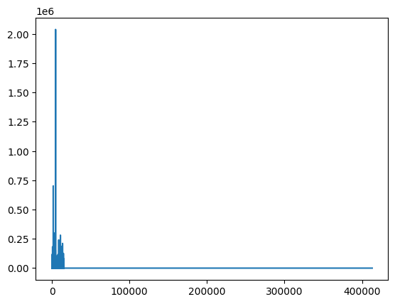

```python
datasev2["AvgClaimAmount"].plot()
```

```python
data=pd.merge(datafreq,datasev2, left_on='PolicyID', right_on='PolicyID', how='inner')
```

```python
data.head()
```

|  | PolicyID | ClaimNb | Exposure | Power | CarAge | DriverAge | Brand | Gas | Region | Density | AvgClaimAmount |
| --- | --- | --- | --- | --- | --- | --- | --- | --- | --- | --- | --- |
| 0 | 1 | 0 | 0.09 | g | 0 | 46 | Japanese (except Nissan) or Korean | Diesel | Aquitaine | 76 | 0.0 |
| 1 | 2 | 0 | 0.84 | g | 0 | 46 | Japanese (except Nissan) or Korean | Diesel | Aquitaine | 76 | 0.0 |
| 2 | 3 | 0 | 0.52 | f | 2 | 38 | Japanese (except Nissan) or Korean | Regular | Nord-Pas-de-Calais | 3003 | 0.0 |
| 3 | 4 | 0 | 0.45 | f | 2 | 38 | Japanese (except Nissan) or Korean | Regular | Nord-Pas-de-Calais | 3003 | 0.0 |
| 4 | 5 | 0 | 0.15 | g | 0 | 41 | Japanese (except Nissan) or Korean | Diesel | Pays-de-la-Loire | 60 | 0.0 |

```python
data.to_csv('filename.csv', index=False)
```

# Analyse Exploratoire des Données (EDA)

## Analyse spatiale : Étude de la variable région

```python
# definir la fonction prerocess1 (pour le traitement initial de donnes )
def preprocess1(data):
  regions_remplacements= {
    "Centre":"Tunis",
    "Ile-de-France":"Sfax",
    "Bretagne":"Sousse",
    "Pays-de-la-Loire":"Nabeul",
    "Aquitaine":"Monastir",
    "Nord-Pas-de-Calais":"Bizerte",
    "Poitou-Charentes":"Mahdia",
    "Basse-Normandie":"Zaghouan",
    "Haute-Normandie":"Jendouba",
    "Limousin":"Le Kef" }
  data = data.loc[:, ~data.columns.duplicated()]

  data['Region'] = data['Region'].replace(regions_remplacements)
  return data
```

```python
data=preprocess1(data)
```

```python
data.head()
```

|  | PolicyID | ClaimNb | Exposure | Power | CarAge | DriverAge | Brand | Gas | Region | Density | AvgClaimAmount |
| --- | --- | --- | --- | --- | --- | --- | --- | --- | --- | --- | --- |
| 0 | 1 | 0 | 0.09 | g | 0 | 46 | Japanese (except Nissan) or Korean | Diesel | Monastir | 76 | 0.0 |
| 1 | 2 | 0 | 0.84 | g | 0 | 46 | Japanese (except Nissan) or Korean | Diesel | Monastir | 76 | 0.0 |
| 2 | 3 | 0 | 0.52 | f | 2 | 38 | Japanese (except Nissan) or Korean | Regular | Bizerte | 3003 | 0.0 |
| 3 | 4 | 0 | 0.45 | f | 2 | 38 | Japanese (except Nissan) or Korean | Regular | Bizerte | 3003 | 0.0 |
| 4 | 5 | 0 | 0.15 | g | 0 | 41 | Japanese (except Nissan) or Korean | Diesel | Nabeul | 60 | 0.0 |

```python
data.info()
```

```
<class 'pandas.core.frame.DataFrame'>
RangeIndex: 413169 entries, 0 to 413168
Data columns (total 11 columns):
 #   Column          Non-Null Count   Dtype
---  ------          --------------   -----
 0   PolicyID        413169 non-null  int64
 1   ClaimNb         413169 non-null  int64
 2   Exposure        413169 non-null  float64
 3   Power           413169 non-null  object
 4   CarAge          413169 non-null  int64
 5   DriverAge       413169 non-null  int64
 6   Brand           413169 non-null  object
 7   Gas             413169 non-null  object
 8   Region          413169 non-null  object
 9   Density         413169 non-null  int64
 10  AvgClaimAmount  413169 non-null  float64
dtypes: float64(2), int64(5), object(4)
memory usage: 34.7+ MB
```

```python
print(data['Region'].unique())
```

```
['Monastir' 'Bizerte' 'Nabeul' 'Sfax' 'Tunis' 'Mahdia' 'Sousse' 'Zaghouan'
 'Le Kef' 'Jendouba']
```

```python
# Agréger les données par région
summary = data.groupby('Region').agg(
    total_claims=('ClaimNb', 'sum'),
    avg_claim_amount=('AvgClaimAmount', 'mean')
).reset_index()

print(summary)
```

```
     Region  total_claims  avg_claim_amount
0   Bizerte           944         55.387258
1  Jendouba           220         36.015995
2    Le Kef           197         53.971170
3    Mahdia           800         65.908616
4  Monastir          1055         56.487727
5    Nabeul          1576         62.993798
6      Sfax          2591         58.945977
7    Sousse          1871         90.010794
8     Tunis          6475         98.283413
9  Zaghouan           452         82.702699
```

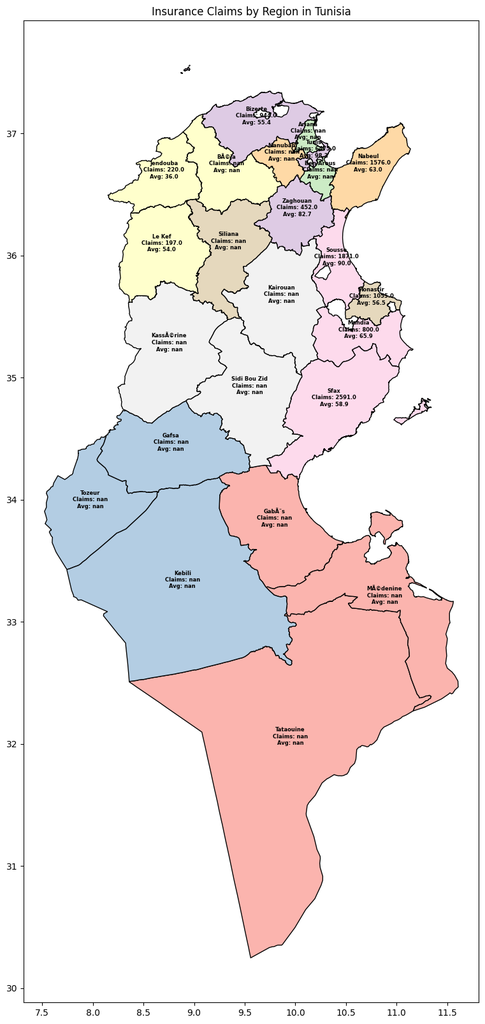

```python
tunisia_map = gpd.read_file('/content/drive/MyDrive/PFA/tn_shp/tn.shp')
# Merge the aggregated data with the map data
tunisia_map = tunisia_map.merge(
    summary,
    left_on='name',
    right_on='Region',
    how='left',
    #suffixes=('_map', '_stats')  # Add suffixes for overlapping columns
)
# Plot the map
gdf=tunisia_map
fig, ax = plt.subplots(figsize=(10, 20))
gdf.plot(ax=ax, edgecolor="black", cmap="Pastel1")

# Add labels with region name, total claims, and avg claim amount
for idx, row in gdf.iterrows():
    centroid = row.geometry.centroid  # Get the center of the region
    text_label = f"{row['name']}\nClaims: {row['total_claims']}\nAvg: {row['avg_claim_amount']:.1f}"

    ax.text(centroid.x, centroid.y, text_label,
            ha="center", fontsize=6, fontweight="bold")

plt.title("Insurance Claims by Region in Tunisia")
plt.show()
```

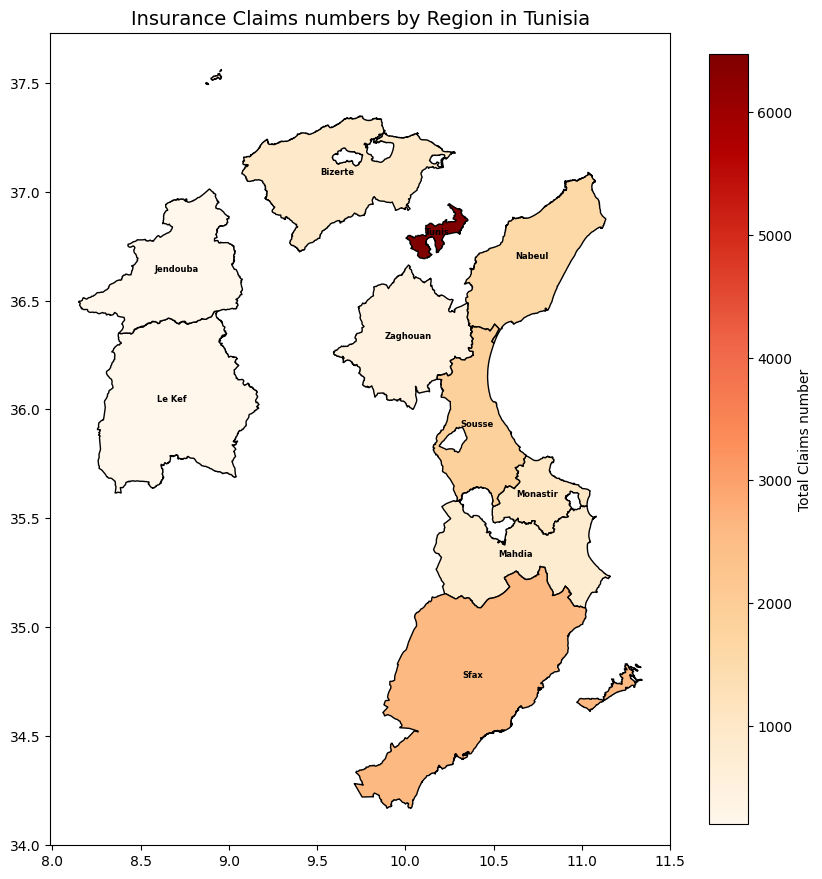

```python
# Load Tunisia shapefile
tunisia_map = gpd.read_file('/content/drive/MyDrive/PFA/tn_shp/tn.shp')

# Merge the aggregated data with the map data
tunisia_map = tunisia_map.merge(
    summary,
    left_on='name',
    right_on='Region',
    how='left'
)
tn_regions=['Sfax' ,'Zaghouan', 'Bizerte' ,'Monastir', 'Nabeul', 'Tunis' ,'Mahdia'
 ,'Jendouba' ,'Sousse', 'Le Kef']
tunisia_map=tunisia_map[tunisia_map['name'].isin(tn_regions)]


# Define colormap
fig, ax = plt.subplots(figsize=(10, 20))
norm = mcolors.Normalize(vmin=tunisia_map['total_claims'].min(), vmax=tunisia_map['total_claims'].max())
cmap = cm.get_cmap('OrRd')  # Orange-Red color map
tunisia_map['color'] = tunisia_map['total_claims'].apply(lambda x: cmap(norm(x)) )

# Plot the map with colors representing 'total_claims'
tunisia_map.plot(ax=ax, edgecolor="black", color=tunisia_map['color'])

# Add bubble markers for avg_claim_amount
scaling_factor = 3 # Adjust for visibility
for idx, row in tunisia_map.iterrows():
    centroid = row.geometry.centroid
    ax.text(centroid.x, centroid.y, row['name'], ha="center", fontsize=6, fontweight="bold", color="black")
    ax.scatter(centroid.x, centroid.y, s=row['avg_claim_amount'] * scaling_factor, color='white', alpha=0, edgecolors='white', linewidth=0.5)

# Add a color bar
sm = cm.ScalarMappable(cmap=cmap, norm=norm)
sm.set_array([])
cbar = plt.colorbar(sm, ax=ax, shrink=0.5)
cbar.set_label("Total Claims number")

plt.title("Insurance Claims numbers by Region in Tunisia", fontsize=14)
plt.show()
```

```python
tunisia_map['centroid'] = tunisia_map.geometry.centroid
```

[figure not shown]

```python
# Create the 3D plot
fig = plt.figure(figsize=(20, 15))
ax = fig.add_subplot(111, projection='3d')

# Plot region borders
for geom in tunisia_map.geometry:
    if geom.geom_type == 'Polygon':
        x, y = geom.exterior.xy
        ax.plot(x, y, 0, color='k', linewidth=0.3, alpha=0.5)
    elif geom.geom_type == 'MultiPolygon':
        for poly in geom.geoms:
            x, y = poly.exterior.xy
            ax.plot(x, y, 0, color='k', linewidth=0.3, alpha=0.5)

# Add cash stacks, labels, and region names
for idx, row in tunisia_map.iterrows():
    centroid = row['centroid']
    x, y = centroid.x, centroid.y
    height = row['avg_claim_amount']/200  # Scale height for visualization

    # Draw the cash stack
    ax.bar3d(x, y, 0, 0.2, 0.2, height, color='green', alpha=0.4, edgecolor='k',zorder=1)

    # Label the average claim amount
    ax.text(
        x + 0.1, y + 0.1, height,  # Offset text position
        f"{row['avg_claim_amount']:,.0f}",
        color='black', fontsize=12, ha='left', va='bottom',
        bbox=dict(facecolor='white', alpha=1, edgecolor='none'),zorder=4  # Background for readability
    )

    # Add region name below the claim amount
    ax.text(
        x + 0.1, y + 0.1, 0,  # Position below the claim value
        f"{row['name']}",  # Use the 'name' column from Natural Earth dataset
        color='blue', fontsize=12, ha='left', va='top',
        bbox=dict(facecolor='white', alpha=1, edgecolor='none'),zorder=4
    )

# Adjust view and style
ax.view_init(elev=30, azim=150)
ax.set_title("Average Claim Amount by Region (3D Cash Stacks)", fontsize=16, pad=20)
ax.set_axis_off()
plt.tight_layout()
plt.show()
```

## Analyse univariée des variables

```python
avgn=data[data["AvgClaimAmount"]<=0].shape[0]
claimn=data[data["ClaimNb"]<=0].shape[0]

print(f"nombre des lignes ou avgclaimamount<0 :{avgn}")
print(f"nombre des lignes ou claimnb<0 : {claimn}")
print(f"nombre des duplicats : {data.duplicated().sum()}")
```

[output not shown]

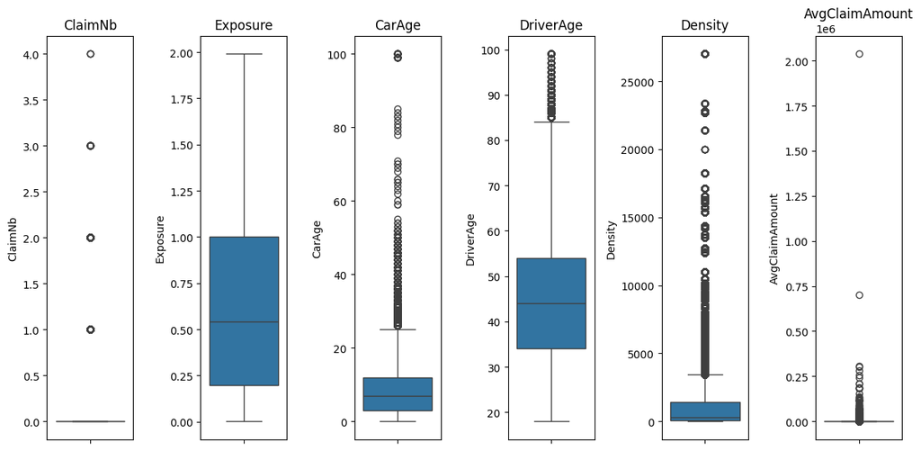

```python
numeric_cols =list( data.select_dtypes(include=['float64', 'int64']).columns)
numeric_cols.remove('PolicyID')
# Créer des boxplots pour chaque variable numérique
plt.figure(figsize=(12, 6))
for i, col in enumerate(numeric_cols, 1):
    plt.subplot(1, len(numeric_cols), i)
    sns.boxplot(y=data[col])
    plt.title(col)
plt.tight_layout()
plt.show()
```

[figure not shown]

```python
# Créer un subplot grid


n_cols = 3  # Nombre de colonnes dans la grille
n_rows = (len(numeric_cols) // n_cols) + 1

plt.figure(figsize=(15, n_rows*5))
for i, col in enumerate(numeric_cols, 1):
    plt.subplot(n_rows, n_cols, i)

    # Histogramme + KDE
    sns.histplot(data[col], kde=True, color="skyblue", bins=30)

    # Titres et styles
    plt.title(f"Distribution de {col}", fontsize=12)
    plt.xlabel("")
    plt.grid(alpha=0.3)

plt.tight_layout()
plt.show()
```

les histogrammes et les box plots qu ont vient de voir montrent la presence des valeurs aberantes dans les variables "avg_claim_amount" et Density, il ya aussi des valeurs aberantes dans les variables ClaimNb , driverAge et CarAge mais ces valeurs abberantes sembles naturelle , donc ont va les remplacer

```python
#traitement des valeurs aberantes pour la variables AvgClaimAmount
#toute valeur plus grande que 100000 euros n est plus logique car le remplacement total d une vehicule de luxe vaut  moins que 100K dans la plus part des cas , sauf ci cette vehicule est  un model special ex : ferrari ,tesla, mclaren,porsche
outliers=data[ (data["AvgClaimAmount"]>100000) ]
#print(outliers)
outliers["Brand"].value_counts()
```

| Brand | count |
| --- | --- |
| Renault, Nissan or Citroen | 16 |
| Volkswagen, Audi, Skoda or Seat | 4 |
| other | 2 |
| Japanese (except Nissan) or Korean | 2 |

**dtype:** int64

on voit que ces outliers ne s agit pas des vehicules de luxe donc c est illogic d avoir un avg_claim_amount aussi eleve , comme il sont tres peut pour influancer le modele (24/15000) j ai decider de les enlever

```python
#gerer les outliers pour la variable Density
# toute valeur de densite plus grande que 20000 est incorrecte , car la ville avec la densiter la plus grande en france est paris ayant une densite de 21000/km2
outliers=data[ (data["Density"]>20000) ]
#print(outliers)
outliers["Region"].value_counts()
```

| Region | count |
| --- | --- |
| Sfax | 458 |

**dtype:** int64

tous les outliers appartenait a la region de Ile de france , donc j ai decider de remplacer leurs densite par la densite de paris 20000

# Préprocessing des Données

## Traitement des valeurs aberrantes et transformation des variables numériques en variables qualitatives

```python
def preprocess2(data):
    outliers = data[(data["AvgClaimAmount"] > 100000)]  # dealing with avgclaimamount outliers
    df = data[~data['PolicyID'].isin(outliers['PolicyID'])]
    outliers = df[(df["Density"] > 20000)]              # dealing with density outliers
    df.loc[df['Density'] > 20000, 'Density'] = 20000

    # Categorize the density variable
    bins = [0, 1000, 5000, 10000, 15000, 20000]
    labels = ['Very Low', 'Low', 'Medium', 'High', 'Very High']
    df['Density_category'] = pd.cut(df['Density'], bins=bins, labels=labels, include_lowest=True)

    # Encoding DriverAge
    bins = [0, 18, 35, 50, 65, float('inf')]
    labels = ['Teen', 'Young Adult', 'Middle-Aged', 'Senior', 'Elderly']
    df['DriverAge_cat'] = pd.cut(df['DriverAge'], bins=bins, labels=labels, right=False)

    # Encoding CarAge
    df['CarAge_category'] = pd.cut(df['CarAge'], bins=[-1, 2, 5, 10, float('inf')],
                                   labels=['New', 'Recent', 'Used', 'Old'])

    # Drop unnecessary variables
    df_final = df.drop(["DriverAge", "CarAge", "Density", "PolicyID"], axis=1)

    # Convert all object columns to categorical
    for col in df_final.select_dtypes(include='object').columns:
        df_final[col] = df_final[col].astype('category')

    # Print dtypes to confirm
    print(df_final.dtypes)

    return df_final
```

```python
df_final=preprocess2(data)
```

```
ClaimNb                int64
Exposure             float64
Power               category
Brand               category
Gas                 category
Region              category
AvgClaimAmount       float64
Density_category    category
DriverAge_cat       category
CarAge_category     category
dtype: object
```

```python
df_final.dtypes
```

|  | 0 |
| --- | --- |
| ClaimNb | int64 |
| Exposure | float64 |
| Power | category |
| Brand | category |
| Gas | category |
| Region | category |
| AvgClaimAmount | float64 |
| Density_category | category |
| DriverAge_cat | category |
| CarAge_category | category |

**dtype:** object

```python
df_final.info()
```

[output not shown]

## Préparation des données pour l'entraînement des modèles

```python
def prepare_for_training(df, target_1='ClaimNb', target_2='AvgClaimAmount', test_size=0.2, random_state=42):
    """
    Prepares training data for two separate models by splitting the dataset
    and ensuring that each target variable is not used in the training of the other.

    Parameters:
    - df: DataFrame, the dataset containing features and target variables
    - target_1: str, name of the first target variable (ClaimNb)
    - target_2: str, name of the second target variable (AvgClaimAmount)
    - test_size: float, proportion of data to be used as the test set
    - random_state: int, random state for reproducibility

    Returns:
    - X_train: DataFrame, features for training both models
    - X_test: DataFrame, features for testing both models
    - y_ClaimNb_train: Series, target variable for ClaimNb training
    - y_ClaimNb_test: Series, target variable for ClaimNb testing
    - y_AvgClaimAmount_train: Series, target variable for AvgClaimAmount training
    - y_AvgClaimAmount_test: Series, target variable for AvgClaimAmount testing
    """

    # Ensure that the dataset contains the required columns
    if target_1 not in df.columns or target_2 not in df.columns:
        raise ValueError("Target variables not found in the dataset")

    # Define feature set excluding both target variables
    feature_cols = [col for col in df.columns if col not in [target_1, target_2]]

    # Split the dataset into training and testing
    train_df, test_df = train_test_split(df, test_size=test_size, random_state=random_state,stratify=df[target_1])

    # Create feature matrices (excluding targets)
    X_train = train_df[feature_cols]
    X_test = test_df[feature_cols]

    # Create target variables
    y_ClaimNb_train = train_df[target_1]
    y_ClaimNb_test = test_df[target_1]

    y_AvgClaimAmount_train = train_df[target_2]
    y_AvgClaimAmount_test = test_df[target_2]

    return train_df,test_df, X_train, X_test, y_ClaimNb_train, y_ClaimNb_test, y_AvgClaimAmount_train, y_AvgClaimAmount_test
```

# Définition et Implémentation des Métriques d'Évaluation

```python
import numpy as np

def gini_coefficient(y_true, y_pred):
    assert len(y_true) == len(y_pred), "Les longueurs de y_true et y_pred doivent être égales"

    # Créer un tableau avec les vraies valeurs et les prédictions
    data = np.c_[y_true, y_pred]

    # Trier par y_pred décroissant (les meilleurs prédits d'abord)
    sorted_data = data[np.argsort(-data[:, 1])]

    # Extraire les y_true triés selon y_pred
    sorted_true = sorted_data[:, 0]

    # Calcul du cumul
    cum_true = np.cumsum(sorted_true)
    total_true = cum_true[-1]

    # Lorenz curve (normalisée)
    lorenz_curve = cum_true / total_true
    lorenz_curve = np.insert(lorenz_curve, 0, 0)
    x_vals = np.linspace(0, 1, len(lorenz_curve))

    # Aire sous la courbe
    lorenz_area = np.trapz(lorenz_curve, x_vals)

    # Gini brut
    gini = 1 - 2 * lorenz_area
    return gini
```

```python
def evaluer_glm(glm_model, X_test, y_test):
    """
    Évalue un modèle GLM en utilisant plusieurs métriques.

    Paramètres :
    - glm_model : modèle GLM entraîné (statsmodels)
    - X_test : données test
    - y_test : vraies valeurs de la variable cible

    Retourne :
    - Un dictionnaire contenant les différentes métriques d'évaluation
    """

    # Prédictions du modèle
    y_pred = glm_model.predict(X_test)

    # Pseudo R² de McFadden
    ll_null = glm_model.null_deviance / -2
    ll_model = glm_model.deviance / -2
    pseudo_r2 = 1 - (ll_model / ll_null)

    # Erreur Quadratique Moyenne (MSE)
    mse = mean_squared_error(y_test, y_pred)

    # Log-vraisemblance
    log_likelihood = glm_model.llf

    # Rapport Déviance / degrés de liberté
    deviance_ratio = glm_model.deviance / glm_model.df_resid

    # Chi² de Pearson (pour Poisson / Binomiale négative)
    pearson_chi2 = np.sum((y_test - y_pred) ** 2 / y_pred)

    # Tableau des coefficients et des p-valeurs
    coeff_p_values = pd.DataFrame({
        "Coefficient": glm_model.params,
        "P-value": glm_model.pvalues
    })

    # Affichage des résultats
    resultats = {
        "Pseudo R² McFadden": pseudo_r2,
        "MSE": mse,
        "Log-vraisemblance": log_likelihood,
        "Rapport Déviance / df": deviance_ratio,
        "Chi² de Pearson": pearson_chi2,
        "Coefficients et P-valeurs": coeff_p_values
    }

    return resultats
```

# Modélisation du Nombre de Sinistres

```python
print(df_final["ClaimNb"].unique())
```

```
[0 1 2 3 4]
```

```python
train_df,test_df,X_train,X_test,y_ClaimNb_train,y_ClaimNb_test,y_AvgClaimAmount_train,y_AvgClaimAmount_test=prepare_for_training(df_final)
```

## Tests d'adéquation pour déterminer la meilleure distribution

```python
X_train.dtypes
```

|  | 0 |
| --- | --- |
| Exposure | float64 |
| Power | category |
| Brand | category |
| Gas | category |
| Region | category |
| Density_category | category |
| DriverAge_cat | category |
| CarAge_category | category |

**dtype:** object

```
Lambda estimé: 0.03910551985380435
Test Chi-Deux: statistique = 905.5985371303801 , p-valeur = 1.020093649380078e-194
Test Kolmogorov-Smirnov: statistique = 0.9616492307062305 , p-valeur = 0.0
Indice de dispersion (devrait être proche de 1): 1.063486356351966
```

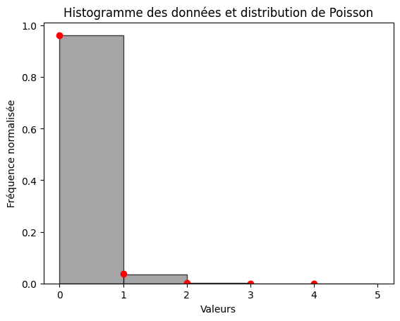

```python
data=y_ClaimNb_train
# Estimation du paramètre lambda (la moyenne)
lambda_hat = np.mean(data)

# Test du Chi-Deux
observed_freq, bins = np.histogram(data, bins=range(0, max(data)+2))
expected_freq = [len(data) * stats.poisson.pmf(i, lambda_hat) for i in range(0, max(data)+1)]

chi2_stat, p_value_chi2 = stats.chisquare(f_obs=observed_freq, f_exp=expected_freq)

# Test de Kolmogorov-Smirnov
ks_stat, p_value_ks = stats.kstest(data, stats.poisson.cdf, args=(lambda_hat,))

# Indice de dispersion
variance = np.var(data)
mean = np.mean(data)

print("Lambda estimé:", lambda_hat)
print("Test Chi-Deux: statistique =", chi2_stat, ", p-valeur =", p_value_chi2)
print("Test Kolmogorov-Smirnov: statistique =", ks_stat, ", p-valeur =", p_value_ks)
print("Indice de dispersion (devrait être proche de 1):", variance / mean)

# Visualisation
plt.hist(data, bins=range(0, max(data)+2), alpha=0.7, color='gray', edgecolor='black', density=True)
plt.plot(range(0, max(data)+1), stats.poisson.pmf(range(0, max(data)+1), lambda_hat), marker='o', linestyle='None', color='red')
plt.title("Histogramme des données et distribution de Poisson")
plt.xlabel("Valeurs")
plt.ylabel("Fréquence normalisée")
plt.show()
```

interpretation : les testes d adequtions montre que la variable ClaimNb ne suit pas une loi de poisson

```python
# Log-vraisemblance de la loi binomiale négative
def neg_binom_log_likelihood(params, data):
    r, p = params
    if r <= 0 or not (0 < p < 1):  # Contraintes
        return np.inf
    likelihood = gammaln(data + r) - gammaln(r) - gammaln(data + 1) + r * np.log(1 - p) + data * np.log(p)
    return -np.sum(likelihood)  # On minimise la log-vraisemblance

# Estimation MLE
initial_guess = [1, 0.5]  # (r, p)
result = minimize(neg_binom_log_likelihood, initial_guess, args=(data,), method='L-BFGS-B', bounds=[(1e-5, None), (1e-5, 1 - 1e-5)])

r_mle, p_mle = result.x
print(f"Paramètres estimés (MLE) : r = {r_mle:.4f}, p = {p_mle:.4f}")
```

```
Paramètres estimés (MLE) : r = 0.6115, p = 0.0601
```

```python
    # Calcul de la fonction de répartition théorique
cdf = lambda x: stats.nbinom.cdf(data, r_mle, p_mle)

    # Test de Cramér–von Mises
result = stats.cramervonmises(data, cdf)
# Afficher les résultats
print(f"Statistique W² : {result.statistic:.4f}")
print(f"P-valeur : {result.pvalue:.4f}")

# Interprétation du résultat
alpha = 0.05
if result.pvalue < alpha:
  print("Rejet de l'hypothèse nulle : les données ne suivent PAS une loi binomiale négative.")
else:
  print("On ne rejette pas l'hypothèse nulle : les données suivent une loi binomiale négative.")
```

```
Statistique W² : 60865.9335
P-valeur : nan
On ne rejette pas l'hypothèse nulle : les données suivent une loi binomiale négative.
```

# Entraînement du modèle de fréquence

```python
#Combine y_ClaimNb_train and X_train into a single DataFrame
df = pd.DataFrame(X_train)
df['y_ClaimNb_train'] = y_ClaimNb_train
df.columns = df.columns.str.replace(r'[^a-zA-Z0-9_]', '_', regex=True)
df['log_exposure'] = np.log(df['Exposure'])
predictors = df.drop(columns=['y_ClaimNb_train','Exposure']).columns
# Define the formula
fml = 'y_ClaimNb_train ~ ' + ' + '.join(predictors[:-1])  # Exclude the target variable


model = smf.glm(fml,
                data=df,
                family=sm.families.NegativeBinomial(alpha=r_mle)  ,
                offset=df['log_exposure']).fit()


"""model = smf.glm(
    formula=fml,
    data=df,
    family=sm.families.NegativeBinomial()  # Use sm.families
).fit()"""
print(model.summary())
```

```
                 Generalized Linear Model Regression Results
==============================================================================
Dep. Variable:        y_ClaimNb_train   No. Observations:               330516
Model:                            GLM   Df Residuals:                   330478
Model Family:        NegativeBinomial   Df Model:                           37
Link Function:                    Log   Scale:                          1.0000
Method:                          IRLS   Log-Likelihood:                -54048.
Date:                Wed, 16 Apr 2025   Deviance:                       76587.
Time:                        05:21:11   Pearson chi2:                 5.65e+05
No. Iterations:                     9   Pseudo R-squ. (CS):           0.002749
Covariance Type:            nonrobust
===============================================================================================================
                                                  coef    std err          z      P>|z|      [0.025      0.975]
---------------------------------------------------------------------------------------------------------------
Intercept                                      -2.0886      0.052    -40.274      0.000      -2.190      -1.987
Power[T.e]                                      0.0661      0.032      2.069      0.039       0.003       0.129
Power[T.f]                                      0.0872      0.031      2.790      0.005       0.026       0.149
Power[T.g]                                      0.0609      0.031      1.964      0.049       0.000       0.122
Power[T.h]                                      0.0828      0.045      1.852      0.064      -0.005       0.170
Power[T.i]                                      0.2291      0.049      4.706      0.000       0.134       0.324
Power[T.j]                                      0.1592      0.050      3.167      0.002       0.061       0.258
Power[T.k]                                      0.2506      0.064      3.926      0.000       0.126       0.376
Power[T.l]                                      0.1435      0.094      1.526      0.127      -0.041       0.328
Power[T.m]                                      0.1751      0.136      1.289      0.197      -0.091       0.441
Power[T.n]                                      0.2685      0.157      1.712      0.087      -0.039       0.576
Power[T.o]                                      0.2332      0.156      1.497      0.134      -0.072       0.539
Brand[T.Japanese (except Nissan) or Korean]    -0.2619      0.052     -5.039      0.000      -0.364      -0.160
Brand[T.Mercedes, Chrysler or BMW]             -0.0067      0.061     -0.110      0.912      -0.125       0.112
Brand[T.Opel, General Motors or Ford]           0.0473      0.051      0.929      0.353      -0.053       0.147
Brand[T.Renault, Nissan or Citroen]            -0.0759      0.045     -1.704      0.088      -0.163       0.011
Brand[T.Volkswagen, Audi, Skoda or Seat]        0.0120      0.052      0.229      0.819      -0.091       0.114
Brand[T.other]                                 -0.1294      0.072     -1.799      0.072      -0.270       0.012
Gas[T.Regular]                                 -0.1422      0.020     -7.244      0.000      -0.181      -0.104
Region[T.Jendouba]                             -0.1124      0.085     -1.317      0.188      -0.280       0.055
Region[T.Le Kef]                                0.2185      0.088      2.470      0.013       0.045       0.392
Region[T.Mahdia]                                0.0038      0.055      0.069      0.945      -0.105       0.112
Region[T.Monastir]                             -0.0724      0.051     -1.412      0.158      -0.173       0.028
Region[T.Nabeul]                               -0.0392      0.047     -0.829      0.407      -0.132       0.053
Region[T.Sfax]                                 -0.0008      0.048     -0.018      0.986      -0.094       0.092
Region[T.Sousse]                               -0.0902      0.046     -1.941      0.052      -0.181       0.001
Region[T.Tunis]                                -0.1305      0.041     -3.194      0.001      -0.211      -0.050
Region[T.Zaghouan]                             -0.1678      0.066     -2.531      0.011      -0.298      -0.038
Density_category[T.Low]                         0.3472      0.022     15.683      0.000       0.304       0.391
Density_category[T.Medium]                      0.2841      0.057      4.997      0.000       0.173       0.396
Density_category[T.High]                        0.4173      0.105      3.983      0.000       0.212       0.623
Density_category[T.Very High]                   0.3873      0.057      6.781      0.000       0.275       0.499
DriverAge_cat[T.Young Adult]                   -0.2936      0.020    -14.978      0.000      -0.332      -0.255
DriverAge_cat[T.Middle-Aged]                   -0.5433      0.019    -28.627      0.000      -0.580      -0.506
DriverAge_cat[T.Senior]                        -0.5888      0.020    -28.824      0.000      -0.629      -0.549
DriverAge_cat[T.Elderly]                       -0.6629      0.026    -25.119      0.000      -0.715      -0.611
CarAge_category[T.Recent]                      -0.0167      0.029     -0.568      0.570      -0.074       0.041
CarAge_category[T.Used]                         0.0505      0.028      1.806      0.071      -0.004       0.105
CarAge_category[T.Old]                         -0.1186      0.029     -4.083      0.000      -0.176      -0.062
===============================================================================================================
```

```python
y_pred=model.predict(df)
print(gini_coefficient(y_pred,y_ClaimNb_train))
```

```
-0.0012965067971286715
```

## Gestion des modalités non significatives

```python
# Extraire les modalités non significatives
modalites_non_significatives = model.pvalues[model.pvalues > 0.05].index.tolist()

print("Modalités non significatives :", modalites_non_significatives)
```

[output not shown]

cherchons a connaitre si les modalite sont mal represente ou seulement non significatives

```python
# commancons par extraires les modalites et leur variable correspondante


# Transformer en dictionnaire {variable: [modalités]}
modalites_dict = {}
for item in modalites_non_significatives:
    match = re.match(r"(.+?)\[T\.(.+)\]", item)
    if match:
        variable, modalite = match.groups()
        if variable not in modalites_dict:
            modalites_dict[variable] = []
        modalites_dict[variable].append(modalite)

# Afficher les variables et leurs modalités non significatives
for variable, modalites in modalites_dict.items():
    print(f"{variable}: {modalites}")
```

```
Power: ['h', 'l', 'm', 'n', 'o']
Brand: ['Mercedes, Chrysler or BMW', 'Opel, General Motors or Ford', 'Renault, Nissan or Citroen', 'Volkswagen, Audi, Skoda or Seat', 'other']
Region: ['Jendouba', 'Mahdia', 'Monastir', 'Nabeul', 'Sfax', 'Sousse']
CarAge_category: ['Recent', 'Used']
```

```python
# Compter les occurrences de chaque modalité
for variable, modalites in modalites_dict.items():
    print(f"\n=== {variable} ===")
    print(df[variable].value_counts().loc[modalites])
```

```
=== Power ===
Power
h    21315
l     3739
m     1467
n     1036
o     1221
Name: count, dtype: int64

=== Brand ===
Brand
Mercedes, Chrysler or BMW           15437
Opel, General Motors or Ford        29922
Renault, Nissan or Citroen         174395
Volkswagen, Audi, Skoda or Seat     26051
other                                7931
Name: count, dtype: int64

=== Region ===
Region
Jendouba     7000
Mahdia      15232
Monastir    25208
Nabeul      30945
Sfax        55867
Sousse      33704
Name: count, dtype: int64

=== CarAge_category ===
CarAge_category
Recent    62715
Used      87663
Name: count, dtype: int64
```

essayons d ameliorer les resultats en effectuant du feature selection et un regroupant les modalites

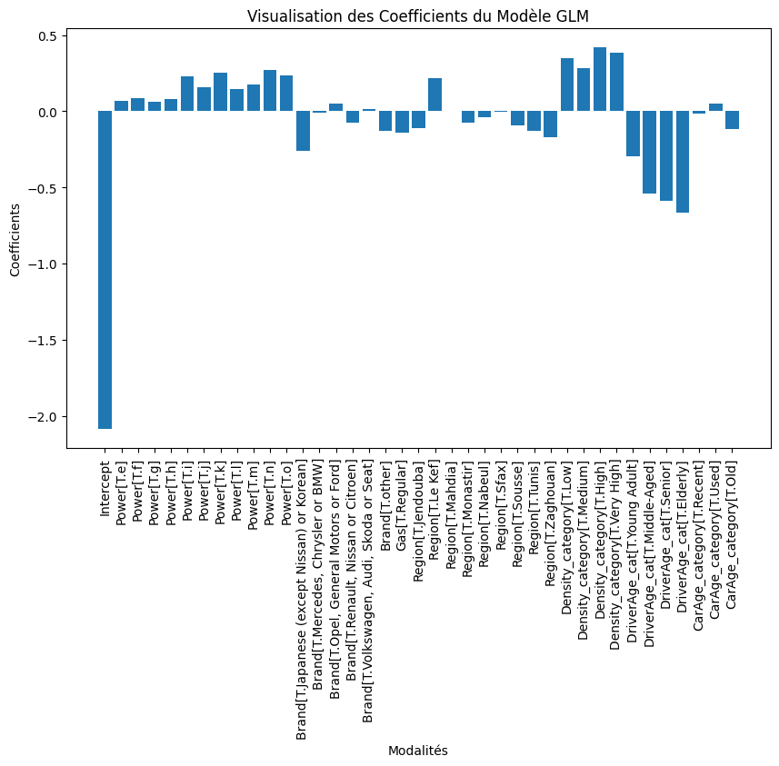

```python
# Visualiser les coefficients
coefficients = model.params
plt.figure(figsize=(10, 6))
plt.bar(coefficients.index, coefficients.values)
plt.xticks(rotation=90)
plt.xlabel('Modalités')
plt.ylabel('Coefficients')
plt.title('Visualisation des Coefficients du Modèle GLM')
plt.show()
```

```python
print(dict(model.pvalues))
```

[output not shown]

```python
# Exemple de données : remplace par ton propre modèle et les résultats des coefficients
# Ici, "coef" et "p-values" sont des résultats fictifs, remplace-les par ceux de ton modèle

# Supposons que tu aies un modèle 'glm' avec des coefficients et p-values
# Exemple de coefficients et p-values pour les variables catégorielles





# 2. Extraire les coefficients pour les modalités non significatives
non_significant_coefs = {key: coefficients[key] for key in modalites_non_significatives}

# 3. Calculer l'écart-type des coefficients non significatifs
coef_values = np.array(list(non_significant_coefs.values()))
std_diff = np.std(coef_values)

# 4. Fusionner les modalités dont les coefficients sont proches (moins de 0.5 écart-type d'écart)
threshold = 0.5 * std_diff

# 5. Fusionner les modalités : on va regrouper celles dont la différence est inférieure au seuil
fusion_groups = []
group = []
for i in range(len(coef_values)):
    if i == 0:
        group.append(modalites_non_significatives[i])
    else:
        if abs(coef_values[i] - coef_values[i-1]) <= threshold:
            group.append(modalites_non_significatives[i])
        else:
            fusion_groups.append(group)
            group = [modalites_non_significatives[i]]

# Ajouter le dernier groupe
if group:
    fusion_groups.append(group)

# 6. Afficher les groupes de modalités fusionnées
print("Groupes de modalités fusionnées :")
for group in fusion_groups:
    print(group)

# Exemple de sortie:
# Groupes de modalités fusionnées :
# ['Power[T.h]', 'Power[T.l]', 'Power[T.m]']
# ['Power[T.n]', 'Power[T.o]']
# ['Brand[T.Mercedes, Chrysler or BMW]', 'Brand[T.Opel, General Motors or Ford]']
# ['Region[T.Jendouba]']
# ['Region[T.Mahdia]', 'Region[T.Monastir]']
```

```
Groupes de modalités fusionnées :
['Power[T.h]']
['Power[T.l]', 'Power[T.m]']
['Power[T.n]', 'Power[T.o]']
['Brand[T.Mercedes, Chrysler or BMW]', 'Brand[T.Opel, General Motors or Ford]']
['Brand[T.Renault, Nissan or Citroen]']
['Brand[T.Volkswagen, Audi, Skoda or Seat]']
['Brand[T.other]', 'Region[T.Jendouba]']
['Region[T.Mahdia]']
['Region[T.Monastir]', 'Region[T.Nabeul]', 'Region[T.Sfax]']
['Region[T.Sousse]']
['CarAge_category[T.Recent]']
['CarAge_category[T.Used]']
```

```python
df_final2=df_final
groupes =[['Power[T.h]','Power[T.l]', 'Power[T.m]','Power[T.n]', 'Power[T.o]'],
 ['Brand[T.Mercedes, Chrysler or BMW]', 'Brand[T.Opel, General Motors or Ford]','Brand[T.Renault, Nissan or Citroen]','Brand[T.Volkswagen, Audi, Skoda or Seat]','Brand[T.other]'],
 ['Region[T.Jendouba]','Region[T.Mahdia]','Region[T.Monastir]', 'Region[T.Nabeul]', 'Region[T.Sfax]','Region[T.Sousse]'],
 ['CarAge_category[T.Recent]','CarAge_category[T.Used]']]
# Fonction pour fusionner les modalités dans X_train
def fusionner_modalites(X_train, groupes):
    for groupe in groupes:
        # Extraction de la variable (nom avant '[') et des modalités (nom après '[')
        variable = groupe[0].split('[')[0]
        # Suppression du "T" dans les modalités pour correspondre à celles dans X_train
        modalites = [modalite.split('[')[1].replace(']', '').replace('T.', '') for modalite in groupe]
        nouvelle_modalite = ' , '.join(modalites)
        # Fusionner les modalités en une nouvelle catégorie
        X_train[variable] = X_train[variable].apply(lambda x: nouvelle_modalite if x in modalites else x)

    return X_train



# Appliquer la fusion des modalités
df_final2= fusionner_modalites(df_final,groupes)
print(df_final2.head())
# Affichage après fusion
print("\nAprès fusion :")
print(df_final2["Power"].value_counts())
```

```
   ClaimNb  Exposure Power                               Brand      Gas  \
0        0      0.09     g  Japanese (except Nissan) or Korean   Diesel
1        0      0.84     g  Japanese (except Nissan) or Korean   Diesel
2        0      0.52     f  Japanese (except Nissan) or Korean  Regular
3        0      0.45     f  Japanese (except Nissan) or Korean  Regular
4        0      0.15     g  Japanese (except Nissan) or Korean   Diesel

                                              Region  AvgClaimAmount  \
0  Jendouba , Mahdia , Monastir , Nabeul , Sfax ,...             0.0
1  Jendouba , Mahdia , Monastir , Nabeul , Sfax ,...             0.0
2                                            Bizerte             0.0
3                                            Bizerte             0.0
4  Jendouba , Mahdia , Monastir , Nabeul , Sfax ,...             0.0

  Density_category DriverAge_cat CarAge_category
0         Very Low   Middle-Aged             New
1         Very Low   Middle-Aged             New
2              Low   Middle-Aged             New
3              Low   Middle-Aged             New
4         Very Low   Middle-Aged             New

Après fusion :
Power
f                    95709
g                    91194
e                    77020
d                    68009
h , l , m , n , o    36025
j                    18037
i                    17615
k                     9536
Name: count, dtype: int64
```

```python
train_df,test_df,X_train,X_test,y_ClaimNb_train,y_ClaimNb_test,y_AvgClaimAmount_train,y_AvgClaimAmount_test=prepare_for_training(df_final2)
```

[output not shown]

```python
#Combine y_ClaimNb_train and X_train into a single DataFrame
df = pd.DataFrame(X_train)
df['y_ClaimNb_train'] = y_ClaimNb_train
df.columns = df.columns.str.replace(r'[^a-zA-Z0-9_]', '_', regex=True)
df['log_exposure'] = np.log(df['Exposure'])
predictors = df.drop(columns=['y_ClaimNb_train','Exposure']).columns
# Define the formula
fml = 'y_ClaimNb_train ~ ' + ' + '.join(predictors[:-1])  # Exclude the target variable

#model = smf.glm(fml,
                #data=df,
                #family=sm.families.NegativeBinomial(alpha=r_mle)  ,
                #offset=df['log_exposure']).fit()


"""model = smf.glm(
    formula=fml,
    data=df,
    family=sm.families.NegativeBinomial()  # Use sm.families
).fit()"""
```

```
'model = smf.glm(\n    formula=fml,\n    data=df,\n    family=sm.families.NegativeBinomial()  # Use sm.families\n).fit()'
```

```python
y_pred=model.predict(df)
print(normalized_gini(y_pred,y_ClaimNb_train))
```

[output not shown]

## Expérimentation avec le modèle ZINB (Zero-Inflated Negative Binomial)

essayons de trouver des meilleurs resultat a l aide modele Zero inflated negative binomial (ZINB)

```python
X_train.dtypes
```

|  | 0 |
| --- | --- |
| Exposure | float64 |
| Power | category |
| Brand | category |
| Gas | category |
| Region | category |
| Density_category | category |
| DriverAge_cat | category |
| CarAge_category | category |

**dtype:** object

```python
fml = 'y_ClaimNb_train ~ ' + ' + '.join(predictors[:-1])  # Exclude the target variable

df = pd.DataFrame(X_train)
df['y_ClaimNb_train'] = y_ClaimNb_train
df.columns = df.columns.str.replace(r'[^a-zA-Z0-9_]', '_', regex=True)
df['log_exposure'] = np.log(df['Exposure'])
predictors = df.drop(columns=['y_ClaimNb_train','Exposure']).columns
# Assuming df is your data and ClaimNb is the dependent variable
# Zero-Inflated Negative Binomial (ZINB) model can be implemented using both logistic regression
# for the zero-inflation part and negative binomial for the count model.
df["y_ClaimNb_trainb"]=(df["y_ClaimNb_train"] == 0).astype(int)

fml2 = 'y_ClaimNb_trainb ~ ' + ' + '.join(predictors[:-1])
# Create the logistic regression for zero inflation
zero_inflation_model = smf.logit(fml2, data=df).fit()

# Predict the zero inflation probabilities
zero_prob = zero_inflation_model.predict(df[predictors])

# Now fit the Negative Binomial model for the count part
binomial_model = smf.glm(fml,
                         family=NegativeBinomial(alpha=r_mle),
                         offset=df['log_exposure'],
                         data=df).fit()

# Get the fitted values from the Negative Binomial model
fitted_binomial = binomial_model.fittedvalues

# Combine the zero-inflation and binomial model predictions
final_predictions = (zero_prob * 0) + ((1 - zero_prob) * fitted_binomial)
```

```python
print(binomial_model.summary())
```

```
                 Generalized Linear Model Regression Results
==============================================================================
Dep. Variable:        y_ClaimNb_train   No. Observations:               330516
Model:                            GLM   Df Residuals:                   330478
Model Family:        NegativeBinomial   Df Model:                           37
Link Function:                    Log   Scale:                          1.0000
Method:                          IRLS   Log-Likelihood:                -54048.
Date:                Fri, 02 May 2025   Deviance:                       76587.
Time:                        15:55:29   Pearson chi2:                 5.65e+05
No. Iterations:                    11   Pseudo R-squ. (CS):           0.002749
Covariance Type:            nonrobust
===============================================================================================================
                                                  coef    std err          z      P>|z|      [0.025      0.975]
---------------------------------------------------------------------------------------------------------------
Intercept                                      -2.0886      0.052    -40.274      0.000      -2.190      -1.987
Power[T.e]                                      0.0661      0.032      2.069      0.039       0.003       0.129
Power[T.f]                                      0.0872      0.031      2.790      0.005       0.026       0.149
Power[T.g]                                      0.0609      0.031      1.964      0.049       0.000       0.122
Power[T.h]                                      0.0828      0.045      1.852      0.064      -0.005       0.170
Power[T.i]                                      0.2291      0.049      4.706      0.000       0.134       0.324
Power[T.j]                                      0.1592      0.050      3.167      0.002       0.061       0.258
Power[T.k]                                      0.2506      0.064      3.926      0.000       0.126       0.376
Power[T.l]                                      0.1435      0.094      1.526      0.127      -0.041       0.328
Power[T.m]                                      0.1751      0.136      1.289      0.197      -0.091       0.441
Power[T.n]                                      0.2685      0.157      1.712      0.087      -0.039       0.576
Power[T.o]                                      0.2332      0.156      1.497      0.134      -0.072       0.539
Brand[T.Japanese (except Nissan) or Korean]    -0.2619      0.052     -5.039      0.000      -0.364      -0.160
Brand[T.Mercedes, Chrysler or BMW]             -0.0067      0.061     -0.110      0.912      -0.125       0.112
Brand[T.Opel, General Motors or Ford]           0.0473      0.051      0.929      0.353      -0.053       0.147
Brand[T.Renault, Nissan or Citroen]            -0.0759      0.045     -1.704      0.088      -0.163       0.011
Brand[T.Volkswagen, Audi, Skoda or Seat]        0.0120      0.052      0.229      0.819      -0.091       0.114
Brand[T.other]                                 -0.1294      0.072     -1.799      0.072      -0.270       0.012
Gas[T.Regular]                                 -0.1422      0.020     -7.244      0.000      -0.181      -0.104
Region[T.Jendouba]                             -0.1124      0.085     -1.317      0.188      -0.280       0.055
Region[T.Le Kef]                                0.2185      0.088      2.470      0.013       0.045       0.392
Region[T.Mahdia]                                0.0038      0.055      0.069      0.945      -0.105       0.112
Region[T.Monastir]                             -0.0724      0.051     -1.412      0.158      -0.173       0.028
Region[T.Nabeul]                               -0.0392      0.047     -0.829      0.407      -0.132       0.053
Region[T.Sfax]                                 -0.0008      0.048     -0.018      0.986      -0.094       0.092
Region[T.Sousse]                               -0.0902      0.046     -1.941      0.052      -0.181       0.001
Region[T.Tunis]                                -0.1305      0.041     -3.194      0.001      -0.211      -0.050
Region[T.Zaghouan]                             -0.1678      0.066     -2.531      0.011      -0.298      -0.038
Density_category[T.Low]                         0.3472      0.022     15.683      0.000       0.304       0.391
Density_category[T.Medium]                      0.2841      0.057      4.997      0.000       0.173       0.396
Density_category[T.High]                        0.4173      0.105      3.983      0.000       0.212       0.623
Density_category[T.Very High]                   0.3873      0.057      6.781      0.000       0.275       0.499
DriverAge_cat[T.Young Adult]                   -0.2936      0.020    -14.978      0.000      -0.332      -0.255
DriverAge_cat[T.Middle-Aged]                   -0.5433      0.019    -28.627      0.000      -0.580      -0.506
DriverAge_cat[T.Senior]                        -0.5888      0.020    -28.824      0.000      -0.629      -0.549
DriverAge_cat[T.Elderly]                       -0.6629      0.026    -25.119      0.000      -0.715      -0.611
CarAge_category[T.Recent]                      -0.0167      0.029     -0.568      0.570      -0.074       0.041
CarAge_category[T.Used]                         0.0505      0.028      1.806      0.071      -0.004       0.105
CarAge_category[T.Old]                         -0.1186      0.029     -4.083      0.000      -0.176      -0.062
===============================================================================================================
```

```python
print(gini_coefficient(final_predictions,y_ClaimNb_train))
```

```
-0.015072961877601543
```

```python
df=pd.DataFrame(X_test)
df['y_ClaimNb_train'] = y_ClaimNb_test
df.columns = df.columns.str.replace(r'[^a-zA-Z0-9_]', '_', regex=True)
df['log_exposure'] = np.log(df['Exposure'])
predictors = df.drop(columns=['y_ClaimNb_train','Exposure']).columns
zero_prob = zero_inflation_model.predict(df[predictors])
predictions=binomial_model.predict(X_test)
final_predictions = (zero_prob * 0) + ((1 - zero_prob) * predictions)
glm_pred=final_predictions
glm_residual=y_ClaimNb_test-glm_pred
print(gini_coefficient(final_predictions,y_ClaimNb_test))
```

```
-0.003669883908877125
```

```python
# Extraire les modalités non significatives
modalites_non_significatives = binomial_model.pvalues[binomial_model.pvalues > 0.05].index.tolist()

print("Modalités non significatives :", modalites_non_significatives)
```

[output not shown]

```python
# Transformer en dictionnaire {variable: [modalités]}
modalites_dict = {}
for item in modalites_non_significatives:
    match = re.match(r"(.+?)\[T\.(.+)\]", item)
    if match:
        variable, modalite = match.groups()
        if variable not in modalites_dict:
            modalites_dict[variable] = []
        modalites_dict[variable].append(modalite)

# Afficher les variables et leurs modalités non significatives
for variable, modalites in modalites_dict.items():
    print(f"{variable}: {modalites}")
```

```
Power: ['h', 'l', 'm', 'n', 'o']
Brand: ['Mercedes, Chrysler or BMW', 'Opel, General Motors or Ford', 'Renault, Nissan or Citroen', 'Volkswagen, Audi, Skoda or Seat', 'other']
Region: ['Jendouba', 'Mahdia', 'Monastir', 'Nabeul', 'Sfax', 'Sousse']
CarAge_category: ['Recent', 'Used']
```

```python
df_final2=df_final
groupes =[['Power[T.h]','Power[T.l]', 'Power[T.m]','Power[T.n]', 'Power[T.o]'],
 ['Brand[T.Mercedes, Chrysler or BMW]', 'Brand[T.Opel, General Motors or Ford]','Brand[T.Renault, Nissan or Citroen]','Brand[T.Volkswagen, Audi, Skoda or Seat]','Brand[T.other]'],
 ['Region[T.Jendouba]','Region[T.Mahdia]','Region[T.Monastir]', 'Region[T.Nabeul]', 'Region[T.Sfax]','Region[T.Sousse]'],
 ['CarAge_category[T.Recent]','CarAge_category[T.Used]']]
# Fonction pour fusionner les modalités dans X_train
def fusionner_modalites(X_train, groupes):
    for groupe in groupes:
        # Extraction de la variable (nom avant '[') et des modalités (nom après '[')
        variable = groupe[0].split('[')[0]
        # Suppression du "T" dans les modalités pour correspondre à celles dans X_train
        modalites = [modalite.split('[')[1].replace(']', '').replace('T.', '') for modalite in groupe]
        nouvelle_modalite = ' , '.join(modalites)
        # Fusionner les modalités en une nouvelle catégorie
        X_train[variable] = X_train[variable].apply(lambda x: nouvelle_modalite if x in modalites else x)

    return X_train



# Appliquer la fusion des modalités
df_final2= fusionner_modalites(df_final,groupes)
print(df_final2.head())
# Affichage après fusion
print("\nAprès fusion :")
print(df_final2["Power"].value_counts())
```

```
   ClaimNb  Exposure Power                               Brand      Gas  \
0        0      0.09     g  Japanese (except Nissan) or Korean   Diesel
1        0      0.84     g  Japanese (except Nissan) or Korean   Diesel
2        0      0.52     f  Japanese (except Nissan) or Korean  Regular
3        0      0.45     f  Japanese (except Nissan) or Korean  Regular
4        0      0.15     g  Japanese (except Nissan) or Korean   Diesel

                                              Region  AvgClaimAmount  \
0  Jendouba , Mahdia , Monastir , Nabeul , Sfax ,...             0.0
1  Jendouba , Mahdia , Monastir , Nabeul , Sfax ,...             0.0
2                                            Bizerte             0.0
3                                            Bizerte             0.0
4  Jendouba , Mahdia , Monastir , Nabeul , Sfax ,...             0.0

  Density_category DriverAge_cat CarAge_category
0         Very Low   Middle-Aged             New
1         Very Low   Middle-Aged             New
2              Low   Middle-Aged             New
3              Low   Middle-Aged             New
4         Very Low   Middle-Aged             New

Après fusion :
Power
f                    95709
g                    91194
e                    77020
d                    68009
h , l , m , n , o    36025
j                    18037
i                    17615
k                     9536
Name: count, dtype: int64
```

```python
train_df,test_df,X_train,X_test,y_ClaimNb_train,y_ClaimNb_test,y_AvgClaimAmount_train,y_AvgClaimAmount_test=prepare_for_training(df_final2)
```

```python
fml = 'y_ClaimNb_train ~ ' + ' + '.join(predictors[:-1])  # Exclude the target variable

df = pd.DataFrame(X_train)
df['y_ClaimNb_train'] = y_ClaimNb_train
df.columns = df.columns.str.replace(r'[^a-zA-Z0-9_]', '_', regex=True)
df['log_exposure'] = np.log(df['Exposure'])
predictors = df.drop(columns=['y_ClaimNb_train','Exposure']).columns
# Assuming df is your data and ClaimNb is the dependent variable
# Zero-Inflated Negative Binomial (ZINB) model can be implemented using both logistic regression
# for the zero-inflation part and negative binomial for the count model.
df["y_ClaimNb_trainb"]=(df["y_ClaimNb_train"] == 0).astype(int)

fml2 = 'y_ClaimNb_trainb ~ ' + ' + '.join(predictors[:-1])
# Create the logistic regression for zero inflation
zero_inflation_model = smf.logit(fml2, data=df).fit()

# Predict the zero inflation probabilities
zero_prob = zero_inflation_model.predict(df[predictors])

# Now fit the Negative Binomial model for the count part
binomial_model = smf.glm(fml,
                         family=NegativeBinomial(alpha=r_mle),
                         offset=df['log_exposure'],
                         data=df).fit()

# Get the fitted values from the Negative Binomial model
fitted_binomial = binomial_model.fittedvalues

# Combine the zero-inflation and binomial model predictions
final_predictions = (zero_prob * 0) + ((1 - zero_prob) * fitted_binomial)
```

```python
print(binomial_model.summary())
```

```
                 Generalized Linear Model Regression Results
==============================================================================
Dep. Variable:        y_ClaimNb_train   No. Observations:               330516
Model:                            GLM   Df Residuals:                   330492
Model Family:        NegativeBinomial   Df Model:                           23
Link Function:                    Log   Scale:                          1.0000
Method:                          IRLS   Log-Likelihood:                -54068.
Date:                Mon, 05 May 2025   Deviance:                       76627.
Time:                        21:38:56   Pearson chi2:                 5.65e+05
No. Iterations:                     8   Pseudo R-squ. (CS):           0.002627
Covariance Type:            nonrobust
============================================================================================================================================================================================================
                                                                                                                                               coef    std err          z      P>|z|      [0.025      0.975]
------------------------------------------------------------------------------------------------------------------------------------------------------------------------------------------------------------
Intercept                                                                                                                                   -2.0940      0.052    -40.560      0.000      -2.195      -1.993
Power[T.e]                                                                                                                                   0.0762      0.032      2.400      0.016       0.014       0.139
Power[T.f]                                                                                                                                   0.0853      0.031      2.733      0.006       0.024       0.147
Power[T.g]                                                                                                                                   0.0626      0.031      2.025      0.043       0.002       0.123
Power[T.h , l , m , n , o]                                                                                                                   0.1166      0.040      2.908      0.004       0.038       0.195
Power[T.i]                                                                                                                                   0.2326      0.048      4.828      0.000       0.138       0.327
Power[T.j]                                                                                                                                   0.1759      0.050      3.537      0.000       0.078       0.273
Power[T.k]                                                                                                                                   0.2573      0.063      4.065      0.000       0.133       0.381
Brand[T.Japanese (except Nissan) or Korean]                                                                                                 -0.2648      0.051     -5.168      0.000      -0.365      -0.164
Brand[T.Mercedes, Chrysler or BMW , Opel, General Motors or Ford , Renault, Nissan or Citroen , Volkswagen, Audi, Skoda or Seat , other]    -0.0468      0.044     -1.065      0.287      -0.133       0.039
Gas[T.Regular]                                                                                                                              -0.1400      0.019     -7.196      0.000      -0.178      -0.102
Region[T.Jendouba , Mahdia , Monastir , Nabeul , Sfax , Sousse]                                                                             -0.0449      0.039     -1.139      0.255      -0.122       0.032
```

[output cut: 14 more lines]

```python
df=pd.DataFrame(X_test)
df['y_ClaimNb_train'] = y_ClaimNb_test
df.columns = df.columns.str.replace(r'[^a-zA-Z0-9_]', '_', regex=True)
df['log_exposure'] = np.log(df['Exposure'])
predictors = df.drop(columns=['y_ClaimNb_train','Exposure']).columns
zero_prob = zero_inflation_model.predict(df[predictors])
predictions=binomial_model.predict(X_test)
final_predictions = (zero_prob * 0) + ((1 - zero_prob) * predictions)
glm_pred=final_predictions
glm_residual=y_ClaimNb_test-glm_pred
print(gini_coefficient(final_predictions,y_ClaimNb_test))
```

```
-0.0034032744174150587
```

```python
glm_pred.to_csv("glm_pred.csv")
glm_residual.to_csv("glm_residual.csv")
y_ClaimNb_test.to_csv("y_test.csv")
```

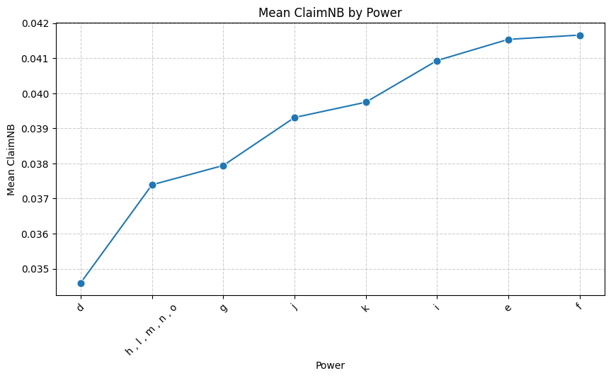

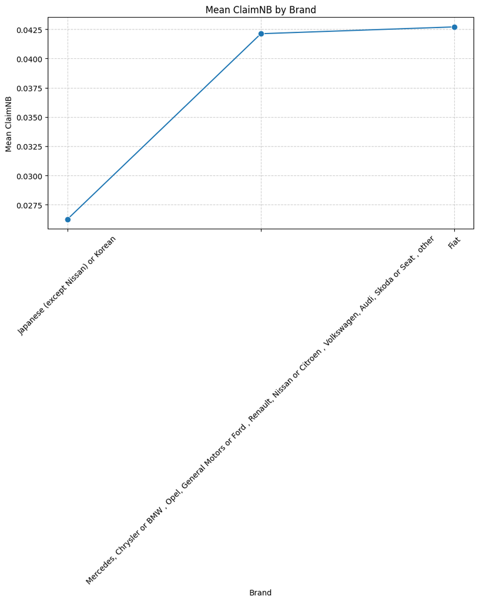

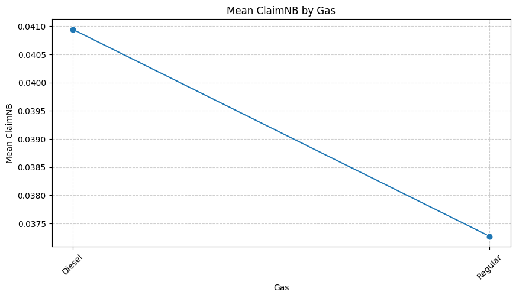

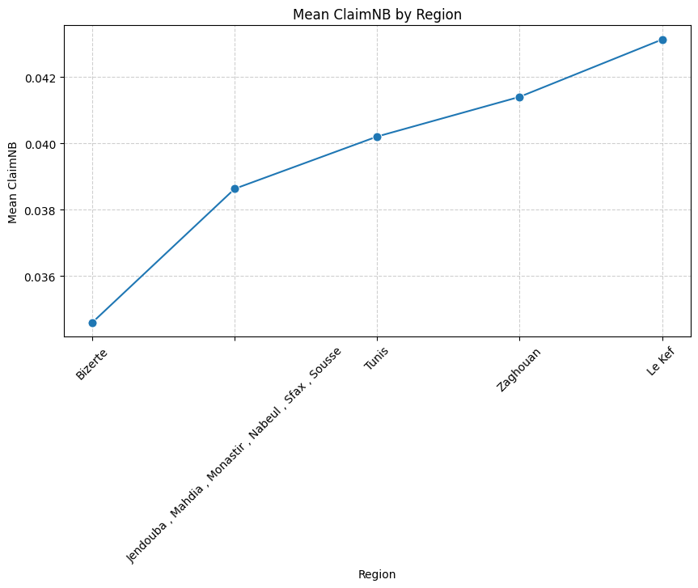

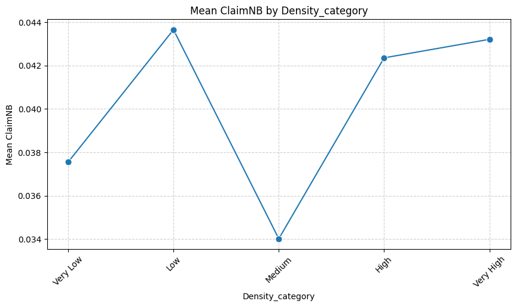

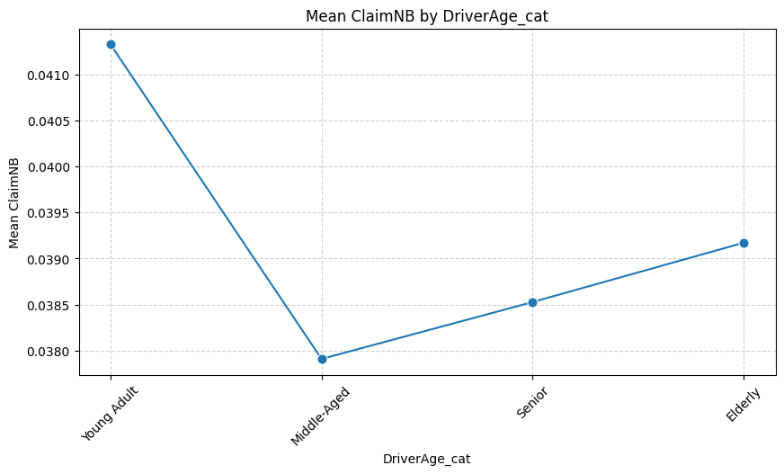

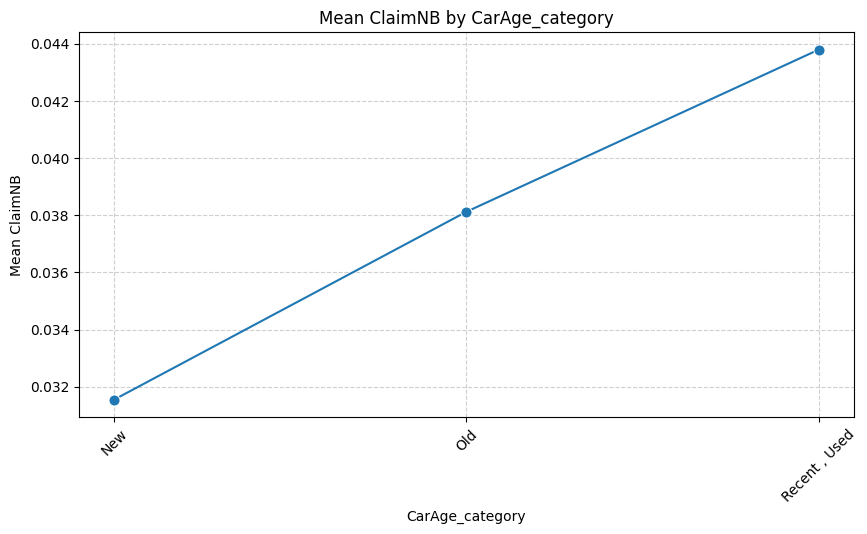

```python
# Select categorical columns
categorical_vars = df.select_dtypes(include=['object', 'category']).columns

for cat_var in categorical_vars:
    plt.figure(figsize=(10, 5))  # Set figure size

    # Compute mean claimnb for each category
    means = df_final.groupby(cat_var)['ClaimNb'].mean().reset_index()

    # Sort categories for better visualization
    means = means.sort_values(by='ClaimNb')

    # Line plot with dots
    sns.lineplot(x=means[cat_var], y=means['ClaimNb'], marker="o", linestyle="-", markersize=8)

    plt.xticks(rotation=45)  # Rotate labels if necessary
    plt.title(f"Mean ClaimNB by {cat_var}")  # Title
    plt.ylabel("Mean ClaimNB")  # Y-axis label
    plt.xlabel(cat_var)  # X-axis label
    plt.grid(True, linestyle="--", alpha=0.6)  # Optional: Add a grid
    plt.show()  # Show the plot
```

# Modélisation du Montant des Sinistres (Modèle de Sévérité)

## Entraînement et évaluation du modèle

```python
y_ClaimNb_train.value_counts()
```

| ClaimNb | count |
| --- | --- |
| 0 | 318223 |
| 1 | 11689 |
| 2 | 579 |
| 3 | 22 |
| 4 | 3 |

**dtype:** int64

```python
train_df,test_df,X_train,X_test,y_ClaimNb_train,y_ClaimNb_test,y_AvgClaimAmount_train,y_AvgClaimAmount_test=prepare_for_training(df_final)
```

```python
    # Find indexes where the column value is zero
zero_indexes =y_AvgClaimAmount_train[y_AvgClaimAmount_train == 0].index.tolist()

    # Remove those rows
y_AvgClaimAmount_train_cleaned = y_AvgClaimAmount_train.drop(index=zero_indexes).reset_index(drop=True)
X_train_cleaned=X_train.drop(index=zero_indexes).reset_index(drop=True)
```

```python
# Get the indexes of rows where 'Exposure' is inf or -inf
inf_indexes = df.index[np.isinf(df['Exposure'])].tolist()
print(len(inf_indexes))
```

```
0
```

```python
X_train_cleaned = pd.get_dummies(X_train_cleaned, drop_first=True)
df = pd.DataFrame(X_train_cleaned)
df['y_AvgClaimAmount_train'] = y_AvgClaimAmount_train_cleaned
df.columns = df.columns.str.replace(r'[^a-zA-Z0-9_]', '_', regex=True)
df['log_exposure'] = np.log(df['Exposure'])
predictors = df.drop(columns=['y_AvgClaimAmount_train','Exposure']).columns
# Define the formula
fml = 'y_AvgClaimAmount_train ~ ' + ' + '.join(predictors[:-1])  # Exclude the target variable


model_sev= smf.glm(fml,
                data=df,
                family=sm.families.Gamma()
               ).fit()
print(model_sev.summary())
```

```
                   Generalized Linear Model Regression Results
==================================================================================
Dep. Variable:     y_AvgClaimAmount_train   No. Observations:                12293
Model:                                GLM   Df Residuals:                    12269
Model Family:                       Gamma   Df Model:                           23
Link Function:               InversePower   Scale:                          5.1235
Method:                              IRLS   Log-Likelihood:            -1.1065e+05
Date:                    Tue, 18 Mar 2025   Deviance:                       13972.
Time:                            23:26:13   Pearson chi2:                 6.29e+04
No. Iterations:                        27   Pseudo R-squ. (CS):           0.002808
Covariance Type:                nonrobust
=================================================================================================================================================================================================================
                                                                                                                                                    coef    std err          z      P>|z|      [0.025      0.975]
-----------------------------------------------------------------------------------------------------------------------------------------------------------------------------------------------------------------
Intercept                                                                                                                                         0.0005   7.15e-05      7.308      0.000       0.000       0.001
Power_e[T.True]                                                                                                                               -6.585e-05   4.87e-05     -1.352      0.176      -0.000    2.96e-05
Power_f[T.True]                                                                                                                                  -0.0001   4.68e-05     -2.383      0.017      -0.000   -1.98e-05
Power_g[T.True]                                                                                                                                  -0.0001   4.55e-05     -3.013      0.003      -0.000   -4.79e-05
Power_h___l___m___n___o[T.True]                                                                                                                  -0.0001   5.74e-05     -2.021      0.043      -0.000   -3.51e-06
Power_i[T.True]                                                                                                                                  -0.0001   6.48e-05     -2.309      0.021      -0.000   -2.26e-05
Power_j[T.True]                                                                                                                               -7.871e-05   7.33e-05     -1.073      0.283      -0.000     6.5e-05
Power_k[T.True]                                                                                                                               -4.866e-05   9.57e-05     -0.508      0.611      -0.000       0.000
Brand_Japanese__except_Nissan__or_Korean[T.True]                                                                                              -3.823e-05   7.27e-05     -0.526      0.599      -0.000       0.000
Brand_Mercedes__Chrysler_or_BMW___Opel__General_Motors_or_Ford___Renault__Nissan_or_Citroen___Volkswagen__Audi__Skoda_or_Seat___other[T.True] -2.846e-05   6.38e-05     -0.446      0.655      -0.000    9.65e-05
Gas_Regular[T.True]                                                                                                                           -3.033e-05   2.68e-05     -1.133      0.257   -8.28e-05    2.22e-05
Region_Jendouba___Mahdia___Monastir___Nabeul___Sfax___Sousse[T.True]                                                                           5.075e-05   5.07e-05      1.002      0.316   -4.85e-05       0.000
```

[output cut: 14 more lines]

```python
df.info()
```

```
<class 'pandas.core.frame.DataFrame'>
RangeIndex: 12293 entries, 0 to 12292
Data columns (total 27 columns):
 #   Column                                                                                                                                 Non-Null Count  Dtype
---  ------                                                                                                                                 --------------  -----
 0   Exposure                                                                                                                               12293 non-null  float64
 1   Power_e                                                                                                                                12293 non-null  bool
 2   Power_f                                                                                                                                12293 non-null  bool
 3   Power_g                                                                                                                                12293 non-null  bool
 4   Power_h___l___m___n___o                                                                                                                12293 non-null  bool
 5   Power_i                                                                                                                                12293 non-null  bool
 6   Power_j                                                                                                                                12293 non-null  bool
 7   Power_k                                                                                                                                12293 non-null  bool
 8   Brand_Japanese__except_Nissan__or_Korean                                                                                               12293 non-null  bool
 9   Brand_Mercedes__Chrysler_or_BMW___Opel__General_Motors_or_Ford___Renault__Nissan_or_Citroen___Volkswagen__Audi__Skoda_or_Seat___other  12293 non-null  bool
```

[output cut: 19 more lines]

# Développement du Modèle Final Coût-Fréquence

modele cout frequence :

```python
def predire_cout_total(df, glm_freq, glm_sev):


    # Prédiction du nombre de sinistres (fréquence)
    df["freq_pred"] = glm_freq.predict(df)

    # Prédiction du coût moyen des sinistres (sévérité) uniquement pour les cas où il y a sinistre
    df["sev_pred"] = glm_sev.predict(df)

    # Calcul du coût total = fréquence prédite × sévérité prédite
    df["cout_total_pred"] = df["freq_pred"] * df["sev_pred"]

    return df["cout_total_pred"]
```

# Approche non lineaire avec XGBoost

## Pretraitement des donnees et modele de base pour xgboost

```python
df=pd.merge(datafreq,datasev2, left_on='PolicyID', right_on='PolicyID', how='inner')
```

```python
target = 'claim_rate'
df["claim_rate"] = df["ClaimNb"] / df["Exposure"]
           # Replace with your target column name
outliers=df[ (df["Density"]>20000) ]                   # dealing with density outliers
df.loc[df['Density'] > 20000, 'Density'] = 20000

X = df.drop(columns=["PolicyID",target,"AvgClaimAmount","ClaimNb","Exposure"],axis=1)
y = df[target]

# --- Handle missing values ---
X = X.fillna(X.median(numeric_only=True))  # Numeric fill
X = X.fillna("missing")                    # Categorical fill

# --- Identify column types ---
numerical_cols = X.select_dtypes(include=['int64', 'float64']).columns.tolist()
categorical_cols = X.select_dtypes(include=['object', 'category']).columns.tolist()

# --- Create preprocessing steps --
rs_params= {'colsample_bytree': 0.6, 'gamma': 0.1, 'learning_rate': 0.05, 'max_depth': 3, 'min_child_weight': 5, 'n_estimators': 500, 'reg_alpha': 0.5, 'reg_lambda': 1, 'subsample': 0.8}
preprocessor = ColumnTransformer(
    transformers=[
        ('num', StandardScaler(), numerical_cols),
        ('cat', OneHotEncoder(), categorical_cols)
    ])
# --- Create a pipeline ---
model = Pipeline(steps=[
    ('preprocessor', preprocessor),
    ('regressor', XGBRegressor(**rs_params))
])

# --- Split data ---
X_train, X_test, y_train, y_test = train_test_split(X, y, test_size=0.2, random_state=42)

# --- Train the model ---
model.fit(X_train, y_train)
```

```
Pipeline(steps=[('preprocessor',
                 ColumnTransformer(transformers=[('num', StandardScaler(),
                                                  ['CarAge', 'DriverAge',
                                                   'Density']),
                                                 ('cat', OneHotEncoder(),
                                                  ['Power', 'Brand', 'Gas',
                                                   'Region'])])),
                ('regressor',
                 XGBRegressor(base_score=None, booster=None, callbacks=None,
                              colsample_bylevel=None, colsample_bynode=None,
                              colsample_bytree=0.6, device=None,
                              early_stopping_round...
                              feature_types=None, gamma=0.1, grow_policy=None,
                              importance_type=None,
                              interaction_constraints=None, learning_rate=0.05,
                              max_bin=None, max_cat_threshold=None,
                              max_cat_to_onehot=None, max_delta_step=None,
                              max_depth=3, max_leaves=None, min_child_weight=5,
                              missing=nan, monotone_constraints=None,
                              multi_strategy=None, n_estimators=500,
                              n_jobs=None, num_parallel_tree=None,
                              random_state=None, ...))])
```

```python
y_pred = model.predict(X_test)
rmse = mean_squared_error(y_test, y_pred)

print(f"Root Mean Squared Error (RMSE): {rmse:.2f}")
mae = mean_absolute_error(y_test, y_pred)
mse = mean_squared_error(y_test, y_pred)

mape = np.mean(np.abs((y_test- y_pred) / y_test)) * 100

# Print results
print(f"MAE : {mae:.4f}")
print(f"MSE : {mse:.4f}")
```

```
Root Mean Squared Error (RMSE): 5.61
MAE : 0.2374
MSE : 5.6074
```

```python
pd.DataFrame(y_pred).to_csv("xgboost_pred.csv")
xgboost_residual=y_test-pd.DataFrame(y_pred)
xgboost_residual.to_csv("xgboost_residual.csv")
X_test.to_csv("X_test.csv")
```

[output not shown]

```python
y_pred = model.predict(X_test)
```

```python
df=pd.merge(datafreq,datasev2, left_on='PolicyID', right_on='PolicyID', how='inner')
```

```python
import pandas as pd
import numpy as np
from sklearn.model_selection import StratifiedKFold
from sklearn.feature_selection import RFECV
from sklearn.pipeline import Pipeline
from sklearn.compose import ColumnTransformer
from sklearn.preprocessing import StandardScaler, OneHotEncoder
from sklearn.impute import SimpleImputer
from xgboost import XGBClassifier
from sklearn.model_selection import KFold
rs_params= {'colsample_bytree': 0.6, 'gamma': 0.1, 'learning_rate': 0.05, 'max_depth': 3, 'min_child_weight': 5, 'n_estimators': 500, 'reg_alpha': 0.5, 'reg_lambda': 1, 'subsample': 0.8}

# Example DataFrame: X (features), y (target)
# X = pd.read_csv("your_data.csv")
# y = X.pop("target")
target = 'claim_rate'
df["claim_rate"] = df["ClaimNb"] / df["Exposure"]
           # Replace with your target column name
outliers=df[ (df["Density"]>20000) ]                   # dealing with density outliers
df.loc[df['Density'] > 20000, 'Density'] = 20000

X = df.drop(columns=["PolicyID",target,"AvgClaimAmount","ClaimNb","Exposure"],axis=1)
y = df[target]
# Identify column types
numeric_features = X.select_dtypes(include=['int64', 'float64']).columns.tolist()
categorical_features = X.select_dtypes(include=['object', 'category']).columns.tolist()

# Preprocessing for numeric features
numeric_transformer = Pipeline(steps=[
    ('imputer', SimpleImputer(strategy='median')),
    ('scaler', StandardScaler())
])

# Preprocessing for categorical features
categorical_transformer = Pipeline(steps=[
    ('imputer', SimpleImputer(strategy='most_frequent')),
    ('onehot', OneHotEncoder(handle_unknown='ignore'))
])

# Combine transformers
preprocessor = ColumnTransformer(
    transformers=[
        ('num', numeric_transformer, numeric_features),
        ('cat', categorical_transformer, categorical_features)
    ]
)

# Create the full pipeline
model = XGBRegressor(device='gpu',**rs_params)

rfecv = RFECV(estimator=model, step=1, cv=KFold(5), scoring='neg_mean_squared_error')
pipeline = Pipeline(steps=[
    ('preprocessor', preprocessor),
    ('feature_selector', rfecv)
])

# Fit pipeline
pipeline.fit(X, y)

# Get selected feature mask (after transformation)
support_mask = pipeline.named_steps['feature_selector'].support_

# Get names of all transformed features
feature_names = pipeline.named_steps['preprocessor'].get_feature_names_out()

# Selected feature names
selected_features = feature_names[support_mask]
print("Selected Features:")
print(selected_features)
```

```
Selected Features:
['num__Density' 'cat__Power_d' 'cat__Brand_Fiat']
```

```python
xgboost_pred=y_pred
xgboost_residual=y_test-xgboost_pred
```

```python
import joblib

# Assume `pipeline` is your trained sklearn Pipeline
joblib.dump(model, "xgboost_pipeline.pkl")
```

```
['xgboost_pipeline.pkl']
```

```python
eldata=X_test
eldata[""]
```

## Comparaison des methodes d’optimisation pour XGBoost

Au cours de mes recherches, les trois méthodes d’optimisation les plus intéressantes que j’ai rencontrées sont : Grid Search, Randomized Search et Optuna. Étant donné que Grid Search est lent et que Randomized Search donne souvent de meilleurs résultats en pratique, j’ai décidé de ne comparer que Randomized Search et Optuna dans cette étude.

```python
!pip install optuna
```

[output not shown]

```python
import optuna
```

```python
import warnings

warnings.filterwarnings(
    "ignore",
    category=UserWarning,
    module="xgboost"
)
```

```python
# Stepwise tuning comparison: RandomizedSearchCV vs Optuna with GPU





# --- 1. Load and preprocess data ---



# --- 2. Common GPU parameters for XGBoost ---
gpu_params = {
    'device': 'gpu',
    'predictor': 'gpu_predictor',
    'objective': 'reg:squarederror',
    'random_state': 42
}

# --- 3. Stepwise tuning settings ---
n_iter = 20
n_trials = 20
stages = [
    ('Stage 1: Complexity',    {'max_depth': [3,5,7], 'min_child_weight': [1,3,5], 'gamma': [0,0.1,0.2]}),
    ('Stage 2: Subsampling',   {'subsample': [0.6,0.8,1.0], 'colsample_bytree': [0.6,0.8,1.0]}),
    ('Stage 3: Regularization',{'reg_alpha': [0,0.1,0.5], 'reg_lambda': [1,1.5,2]}),
    ('Stage 4: Learning Rate', {'learning_rate': [0.01,0.05,0.1], 'n_estimators': [500,1000,1500]})
]

best_params_rs = {}
best_params_opt = {}
total_time_rs = 0
total_time_opt = 0
X = pd.get_dummies(X)
X_train, X_test, y_train, y_test = train_test_split(X, y, test_size=0.2, random_state=42)

# --- 4. Executing stepwise tuning ---
for stage_name, param_grid in stages:
    print(f"\n--- {stage_name} ---")

    # 4a. RandomizedSearchCV
    rs = RandomizedSearchCV(
        estimator=XGBRegressor(**gpu_params, **best_params_rs),
        param_distributions=param_grid,
        n_iter=n_iter,
        scoring='neg_root_mean_squared_error',
        cv=5,
        n_jobs=-1,
        random_state=42,
    )
    start_rs = time.time()
    rs.fit(X_train, y_train)
    end_rs = time.time()
    total_time_rs += (end_rs - start_rs)
    best_params_rs.update(rs.best_params_)
    print(f"RS best params: {rs.best_params_} | time: {end_rs - start_rs:.2f}s")

    # 4b. Optuna
    def objective(trial):
        params = {p: trial.suggest_categorical(p, choices) for p, choices in param_grid.items()}
        params.update(gpu_params)
        params.update(best_params_opt)
        model = XGBRegressor(**params)
        model.fit(X_train, y_train, verbose=False)
        preds = model.predict(X_train)
            # use cross_val_score with our stratified folds
        scores = cross_val_score(
        model, X_train, y_train,
        cv=5,

        scoring='neg_root_mean_squared_error',
        n_jobs=-1
        )
        # return the mean RMSE across folds
        return -np.mean(scores)


    study = optuna.create_study(direction='minimize')
    start_opt = time.time()
    study.optimize(objective, n_trials=n_trials, show_progress_bar=False)
    end_opt = time.time()
    total_time_opt += (end_opt - start_opt)
    best_params_opt.update(study.best_params)
    print(f"Optuna best params: {study.best_params} | time: {end_opt - start_opt:.2f}s")

# --- 5. Final evaluation ---
model_rs = XGBRegressor(**gpu_params, **best_params_rs)
model_opt = XGBRegressor(**gpu_params, **best_params_opt)
model_rs.fit(X_train, y_train)
model_opt.fit(X_train, y_train)
```

```
--- Stage 1: Complexity ---
```

[output not shown]

[output cut: 82 more lines]

[output not shown]

```python
# Parameters you're interested in:
selected_params = [
    'max_depth', 'min_child_weight', 'gamma',
    'subsample', 'colsample_bytree',
    'reg_alpha', 'reg_lambda',
    'learning_rate', 'n_estimators'
]

print("\n=== Comparison Summary ===")
print(f"RandomizedSearchCV ->  Time: {total_time_rs:.2f}s, Iterations: {n_iter * len(stages)}")
print(f"Optuna            ->   Time: {total_time_opt:.2f}s, Trials: {n_trials * len(stages)}")

# Randomized Search model:
rs_filtered_params = {key: val for key, val in model_rs.get_params().items() if key in selected_params}
print("Filtered RS Params:", rs_filtered_params)

# Optuna model:
optuna_filtered_params = {key: val for key, val in model_opt.get_params().items() if key in selected_params}
print("Filtered Optuna Params:", optuna_filtered_params)
```

```
=== Comparison Summary ===
RandomizedSearchCV ->  Time: 303.28s, Iterations: 80
Optuna            ->   Time: 652.73s, Trials: 80
Filtered RS Params: {'colsample_bytree': 0.6, 'gamma': 0.1, 'learning_rate': 0.05, 'max_depth': 3, 'min_child_weight': 5, 'n_estimators': 500, 'reg_alpha': 0.5, 'reg_lambda': 1, 'subsample': 0.8}
Filtered Optuna Params: {'colsample_bytree': 1.0, 'gamma': 0.1, 'learning_rate': 0.05, 'max_depth': 3, 'min_child_weight': 3, 'n_estimators': 1000, 'reg_alpha': 0.5, 'reg_lambda': 2, 'subsample': 1.0}
```

Les deux modèles, Randomized Search et Optuna, donnentddes parametres differents , mais Randomized Search est plus rapide. il nous reste de comparer les performances du modele pour les differentes parametres optimisees donnees par chaque methode on va utiliser la validation croisee comme c est la methode d evaluation sur la quel les modeles on baser pour choisir les parametres .

## Comparaison avec le model de base

```python
from sklearn.model_selection import cross_val_score, KFold
from xgboost import XGBRegressor
import numpy as np

cv = KFold(n_splits=5, shuffle=True, random_state=42)

models = {
    "Baseline":XGBRegressor(),
    "RandomizedSearch":XGBRegressor(**rs_filtered_params),
    "optuna": XGBRegressor(**optuna_filtered_params)

}

for name, model in models.items():
    scores = cross_val_score(model, X_train, y_train, cv=cv, scoring='neg_root_mean_squared_error', n_jobs=-1)
    print(f"{name} CV RMSE: {-np.mean(scores)} (± {np.std(scores):.4f})")
```

```
Baseline CV RMSE: 0.20319831669330596 (± 0.0020)
RandomizedSearch CV RMSE: 0.20202528536319733 (± 0.0020)
optuna CV RMSE: 0.20204917788505555 (± 0.0020)
```

## Interpretaion

Donc la methode randomized search n a pas seulement etait pus rapide mais elle est a aussi donner un score rmse legerment meilleur , doc elle est plus pratique dans notre cas

## test du modele rs sur le test set

```python
rs_filtered_params={'colsample_bytree': 0.6, 'gamma': 0.1, 'learning_rate': 0.05, 'max_depth': 3, 'min_child_weight': 5, 'n_estimators': 500, 'reg_alpha': 0.5, 'reg_lambda': 1, 'subsample': 0.8}


# Prédictions sur le test set

model_rs=XGBRegressor(**rs_filtered_params)
model_rs.fit(X_train,y_ClaimNb_train)
y_pred = model_rs.predict(X_test)

# Calcul des métriques
mae = mean_absolute_error(y_test, y_pred)
mse = mean_squared_error(y_test, y_pred)
rmse = np.sqrt(mse)

models = {
    "RandomizedSearch": model_rs,

}
```

[output not shown]

[output cut: 74 more lines]

[output not shown]

```python
# Compute and collect results

metrics = {
    "MAE": mean_absolute_error,
    "MSE": mean_squared_error,
    "R2": r2_score
}

X = pd.get_dummies(X)
X_train, X_test, y_train, y_test = train_test_split(X, y, test_size=0.2, random_state=42)


results = []
for name, mdl in models.items():
    y_pred = mdl.predict(X_test)
    row = {"Model": name}
    for m_name, fn in metrics.items():
        row[m_name] = fn(y_test, y_pred)
    results.append(row)

# Build a DataFrame

test = pd.DataFrame(results).set_index("Model")
print(test)
```

```
                       MAE       MSE        R2
Model
RandomizedSearch  0.075355  0.042418  0.011212
```

## interpretation a l aide de SHAP

```python
! pip install shap
```

```python
import shap
import pandas as pd
```

```python
df=pd.merge(datafreq,datasev2, left_on='PolicyID', right_on='PolicyID', how='inner')
df=preprocess1(df)
```

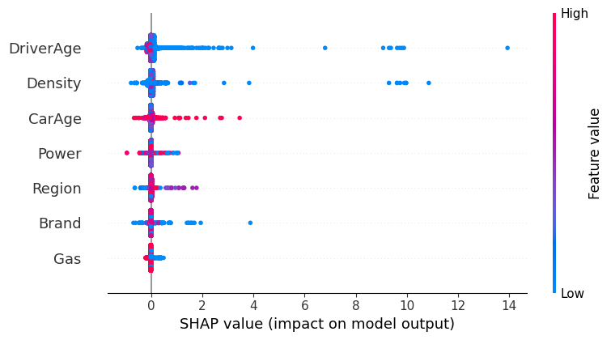

```python
import pandas as pd
import xgboost as xgb
import shap
from sklearn.model_selection import train_test_split
from sklearn.metrics import accuracy_score
from sklearn.preprocessing import LabelEncoder
import matplotlib.pyplot as plt

# === STEP 1: Load your data ===
# Replace 'your_data.csv' with your dataset




# === STEP 3: Encode categorical features if necessary ===
for col in df.select_dtypes(include='object').columns:
    df[col] = LabelEncoder().fit_transform(df[col])


target = 'claim_rate'
df["claim_rate"] = df["ClaimNb"] / df["Exposure"]
           # Replace with your target column name
outliers=df[ (df["Density"]>20000) ]                   # dealing with density outliers
df.loc[df['Density'] > 20000, 'Density'] = 20000

X = df.drop(columns=["PolicyID",target,"AvgClaimAmount","ClaimNb","Exposure"],axis=1)
y = df[target]

# === STEP 5: Train/test split ===
X_train, X_test, y_train, y_test = train_test_split(X, y, test_size=0.2, random_state=42)

# === STEP 6: Train XGBoost model ===
model = xgb.XGBRegressor(use_label_encoder=False, eval_metric='mlogloss',**rs_params)
model.fit(X_train, y_train)

# === STEP 7: Evaluate model ===
y_pred = model.predict(X_test)


# === STEP 8: Interpret using SHAP ===
explainer = shap.TreeExplainer(model)
shap_values = explainer.shap_values(X_test)

# === STEP 9: Plot summary ===
shap.summary_plot(shap_values, X_test, feature_names=X.columns.tolist())

# Optional: Force plot for one sample
# shap.initjs()
# shap.force_plot(explainer.expected_value[0], shap_values[0][0], X_test.iloc[0])
```

## interpretation

Trois indications importantes peuvent être obtenues en analysant le graphique SHAP ci-dessus. Tout d'abord, les variables situées en haut du graphique ont l'impact le plus significatif sur les prédictions, tandis que celles en bas ont une influence moindre. Ensuite, la position de chaque bande de variable indique l'étendue de son impact sur les prédictions. Enfin, chaque point représente une observation, et la densité autour d'une région indique la concentration des valeurs de la variable correspondante.

les constats suivants peuvent être tirés :

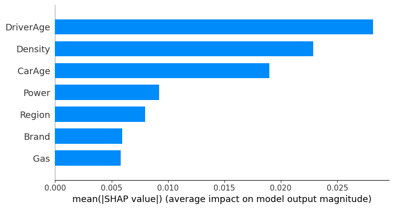

```python
shap.summary_plot(shap_values, X, plot_type="bar")
```

## Interpretation :

On observe que DriverAge est la variable la plus influente, suivie de Density et CarAge, ce qui indique que l’âge du conducteur, la densité de population et l’âge du véhicule jouent un rôle central dans les décisions du modèle. Les variables Power, Region, Brand et Gas ont une contribution plus faible, avec un impact globalement limité sur les prédictions.